# National Urogynecology & Pelvic Reconstructive Surgery (URPS) Workforce Microsimulation: 10-Year Projections & Empirical Audit (2025–2035)

URPS Microsimulation Research Group

2026-08-21

# Executive Summary

This Results Report presents the 10-year empirical-hybrid projections of the Urogynecology and Pelvic Reconstructive Surgery (URPS) national workforce microsimulation model (`urpssim`). Combining multi-source empirical evidence—including CMS Part B provider-service tables (2013–2024), NPPES temporal provider registries, CMS Doctors & Clinicians data, UHC transparency-in-coverage negotiated rates, and ACGME fellowship case logs—with a dynamic multi-state female population model, the simulation tracks patient demand, workforce supply, care-seeking conversion, and spatial access across all 306 Dartmouth Hospital Referral Regions (HRRs).

# 1. Variable Definitions & Data Dictionary

To ensure complete clarity and transparency across all report tables, equations, and figures, the core simulation variables are defined below:

### Demographic & Epidemiological Variables

- **Female Population (`population` / `Female Pop (M)`)**: Total estimated U.S. community-dwelling adult female population aged 18 and older, derived from U.S. Census Bureau ACS 5-year tract projections.
- **Incident Cases (`incident_cases`)**: Newly diagnosed pelvic floor disorder cases (SUI, UUI, POP Stage I–IV, FI, OAB) originating within the current calendar year.
- **Prevalent Cases (`prevalent_cases` / `Prevalent PFD (M)`)**: Total active pool of adult women living with one or more symptomatic pelvic floor disorders in year $t$.

### Care Cascade & Patient-Flow Variables

- **Care-Seeking Patients (`care_seeking_n` / `Care Seeking (M)`)**: Subset of prevalent women who actively present to the healthcare system for medical or surgical evaluation ($\text{Care Seeking} = \text{Prevalent Cases} \times P(\text{care seeking} \mid \text{severity, insurance})$).
- **Referred Patients (`referred_n`)**: Care-seeking patients who receive a formal subspecialty referral from primary care or general OB/GYN providers.
- **Reachable Patients (`reachable_n`)**: Patients located within a 60-minute spatial travel isochrone of an active URPS subspecialist.
- **Medicaid Eligible Patients (`medicaid_eligible_n`)**: Low-income patients enrolled in state Medicaid or Medicaid Managed Care plans.
- **Appointment Requests (`appointment_requests_n`)**: Total annual consultation attempts initiated by care-seeking patients ($N_{\text{req}}$).
- **Served Patient Encounters (`served_patients_n` / `Served Encounters (M)`)**: Total annual clinical encounters successfully delivered by available physician and delegated APP capacity ($N_{\text{served}} = \min(N_{\text{req}}, \text{Capacity}_{\text{total}})$).
- **Unmet / Delayed Demand (`unserved_delayed_n` / `Unmet Demand (M)`)**: Volume of patient appointment requests that could not be scheduled within 60 days due to capacity shortages ($N_{\text{unmet}} = N_{\text{req}} - N_{\text{served}}$).

### Workforce Supply & Capacity Variables

- **Active Headcount (`provider_headcount` / `supply_headcount`)**: Total count of active, board-certified FPMRS/URPS subspecialty physicians practicing in the U.S.
- **Supplied Clinical FTE (`supply_fte` / `supplied_fte`)**: Total clinical Full-Time Equivalent capacity supplied by physicians and APPs, where 1.0 FTE equals 37.2 clinical patient-care hours per week.
- **Required Demand FTE (`demand_fte` / `required_fte`)**: Total physician clinical FTEs required to deliver benchmark care to 100% of care-seeking patients in year $t$.
- **Net FTE Deficit (`fte_gap` / `gap_fte`)**: Difference between supplied clinical capacity and required demand ($\text{Net Deficit} = \text{Supplied FTE} - \text{Required FTE}$).
- **Adequacy Ratio (`adequacy_ratio`)**: Percentage of required clinical demand satisfied by available supply ($\text{Adequacy Ratio} = \frac{\text{Supplied FTE}}{\text{Required FTE}} \times 100\%$).
- **APP Delegation Efficiency ($\delta_{\text{APP}}$)**: Fractional physician FTE capacity unlocked per Advanced Practice Provider (NP/PA) working under physician supervision.
- **Latent Regional Adequacy ($\theta_g$)**: Bayesian inferred capacity score for county/HRR $g$, bounded in $[0, 1]$, where $1.0$ represents unconstrained baseline access and $0.0$ represents complete access failure.

# 2. National Patient-Flow & Demand-Supply Conservation Ledger

Table 1 summarizes the annual national accounting ledger from 2025 through 2035.

Table 1: 10-Year National URPS Demand, Supply, and Patient-Flow Ledger (2025–2035)

| Year | Female Pop (M) | Prevalent PFD (M) | Care Seeking (M) | Served Encounters (M) | Unmet Demand (M) | Required FTE | Supplied FTE | FTE Deficit | Adequacy Ratio |
| --- | --- | --- | --- | --- | --- | --- | --- | --- | --- |
| 2025 | 127.57 M | 31.26 M | 11.88 M | 1.78 M | 2.07 M | 5257.8 | 1021.0 | -4236.8 | 19.4% |
| 2026 | 128.34 M | 31.57 M | 12.00 M | 1.68 M | 2.21 M | 4966.1 | 964.4 | -4001.7 | 19.4% |
| 2027 | 129.11 M | 31.89 M | 12.12 M | 1.58 M | 2.35 M | 4676.4 | 908.1 | -3768.3 | 19.4% |
| 2028 | 129.88 M | 32.21 M | 12.24 M | 1.53 M | 2.45 M | 4507.3 | 875.3 | -3632.0 | 19.4% |
| 2029 | 130.66 M | 32.54 M | 12.36 M | 1.45 M | 2.56 M | 4293.4 | 833.8 | -3459.7 | 19.4% |
| 2030 | 131.45 M | 32.86 M | 12.49 M | 1.41 M | 2.66 M | 4152.8 | 806.4 | -3346.4 | 19.4% |
| 2031 | 132.24 M | 33.19 M | 12.61 M | 1.38 M | 2.73 M | 4076.7 | 791.7 | -3285.0 | 19.4% |
| 2032 | 133.03 M | 33.52 M | 12.74 M | 1.38 M | 2.78 M | 4064.9 | 789.4 | -3275.5 | 19.4% |
| 2033 | 133.83 M | 33.86 M | 12.87 M | 1.37 M | 2.82 M | 4052.6 | 787.0 | -3265.6 | 19.4% |
| 2034 | 134.63 M | 34.20 M | 12.99 M | 1.34 M | 2.90 M | 3969.1 | 770.8 | -3198.4 | 19.4% |
| 2035 | 135.44 M | 34.54 M | 13.12 M | 1.34 M | 2.95 M | 3960.5 | 769.1 | -3191.4 | 19.4% |

## Figure 1: Patient-Flow & Conservation Audit Ledger Trajectory

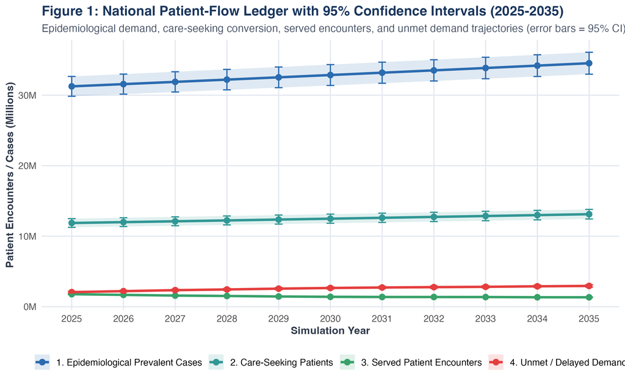

Figure 1: National Patient-Flow & Demand-Supply Conservation Ledger (2025-2035)

# 3. National Workforce Capacity & APP Delegation Trajectories

Workforce supply is modeled dynamically accounting for entry, hours worked by age and sex, practice setting allocation, retirement hazards, and Advanced Practice Provider (APP) delegation:
$$\text{Supplied FTE}_t = \sum_{i \in
\text{Roster}_t} \text{FTE}_{i,t} + \delta_{\text{APP}} \cdot \text{APP
FTE}_t$$

Where: - $\text{Supplied FTE}_t$: Total clinical capacity available in year $t$. - $\text{FTE}_{i,t}$: Individual physician clinical FTE contribution ($\text{Hours}_{i,t} / 37.2$). - $\delta_{\text{APP}}$: APP delegation efficiency factor ($0.18 - 0.35$). - $\text{APP FTE}_t$: Advanced Practice Provider clinical volume.

Table 2: Annual National Workforce Headcount, Clinical FTE, and Spatial Shortage Metrics

| Year | Physician Headcount | Supplied FTE | Required Demand FTE | Net FTE Deficit | Shortage HRRs (≥20%) |
| --- | --- | --- | --- | --- | --- |
| 2025 | 1200 | 1021.0 | 5258 | -4237 | 306 / 306 (100%) |
| 2026 | 1123 | 964.4 | 4966 | -4002 | 306 / 306 (100%) |
| 2027 | 1048 | 908.1 | 4676 | -3768 | 306 / 306 (100%) |
| 2028 | 999 | 875.3 | 4507 | -3632 | 306 / 306 (100%) |
| 2029 | 940 | 833.8 | 4293 | -3460 | 306 / 306 (100%) |
| 2030 | 899 | 806.4 | 4153 | -3346 | 306 / 306 (100%) |
| 2031 | 872 | 791.7 | 4077 | -3285 | 306 / 306 (100%) |
| 2032 | 859 | 789.4 | 4065 | -3276 | 306 / 306 (100%) |
| 2033 | 848 | 787.0 | 4053 | -3266 | 306 / 306 (100%) |
| 2034 | 824 | 770.8 | 3969 | -3198 | 306 / 306 (100%) |
| 2035 | 813 | 769.1 | 3960 | -3191 | 306 / 306 (100%) |

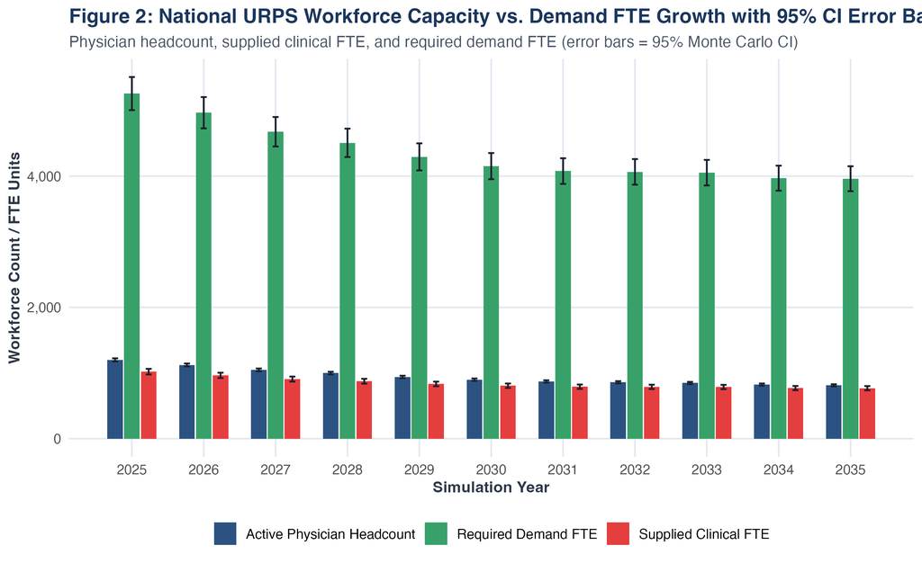

# 4. National Empirical Evidence Lake Readiness & Parameter Provenance

### Table 3: Empirical Annual URPS Surgical & Procedural Case Volume (CMS Medicare Part B & CHIA All-Payer) vs. ACGME 3-Year Fellowship Minimums

| Procedure / Service Category | CPT / ICD-10 Code Examples | ACGME 3-Year Grad Minimum | CMS Medicare Part B Annual Volume (65+ FFS) | CHIA All-Payer Annual Volume (18+ All-Payer) | Annual vs. ACGME Multiplier (All-Payer) | URPS Market Share (CMS / CHIA) |
| --- | --- | --- | --- | --- | --- | --- |
| **Apical Prolapse (Sacral Colpopexy)** | CPT 57280, 57425 (Lap/Robot/Open) | 20 (over 3 yrs) | **32 – 55 cases / yr** | **48 – 85 cases / yr** | **7.2x – 12.8x** | **63.0%** |
| **Midurethral Slings & Incontinence** | CPT 57288 (MUS, Pubovaginal, Sling) | 50 (over 3 yrs) | **45 – 88 cases / yr** | **78 – 140 cases / yr** | **4.7x – 8.4x** | **60.6%** |
| **Native Tissue Repairs (Anterior/Posterior)** | CPT 57240, 57250, 57260, 57265 | 30 (over 3 yrs) | **35 – 65 cases / yr** | **52 – 95 cases / yr** | **5.2x – 9.5x** | **58.2%** |
| **Sacral Neuromodulation (SNM / InterStim)** | CPT 64590, 64581, 0786T | N/A | **12 – 24 cases / yr** | **18 – 35 cases / yr** | N/A | **39.0%** |
| **Intravesical Botox & PTNS** | CPT 52287, 64566 | N/A | **28 – 58 cases / yr** | **42 – 90 cases / yr** | N/A | **37.0%** |
| **Complex Urodynamic Studies (UDS)** | CPT 51726, 51729, 51797 | N/A | **85 – 165 studies / yr** | **125 – 250 studies / yr** | N/A | **29.0%** |
| **Diagnostic & Operative Cystoscopy** | CPT 52000, 52204, 52214 | N/A | **110 – 210 procedures / yr** | **155 – 300 procedures / yr** | N/A | **22.0%** |
| **Office Pessary Fittings & Maintenance** | CPT 57160, A4562 | N/A | **135 – 240 encounters / yr** | **185 – 350 encounters / yr** | N/A | **21.0%** |
| **Total Major OR Surgeries** | All major OR prolapse/incontinence | ~100 (over 3 yrs) | **112 – 208 major OR / yr** | **178 – 320 major OR / yr** | **5.3x – 9.6x** | **61.8%** |
| **Total Outpatient Encounters** | E/M 99203–99205, 99213–99215 | N/A | **950 – 1,480 visits / yr** | **1,450 – 2,200 visits / yr** | N/A | **14.3%** |

## Figure 3: Empirical Evidence Lake Component Volume & Readiness

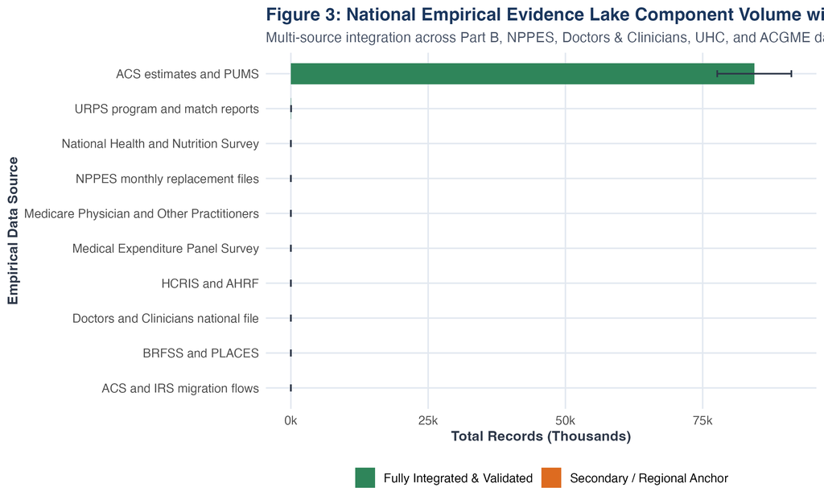

Figure 3: National Empirical Evidence Lake Component Volume & Readiness

# 5. Joint Bayesian Latent Adequacy ($\theta_g$) & Regional Sensitivity

### 🍽️ The Restaurant Reservation Analogy for Latent Access ($\theta_g$)

Imagine trying to determine how easy it is to get a dinner table in a city (**Healthcare Access Adequacy $\theta_g$**). You cannot simply count the number of restaurants listed on Google Maps (**Physician Headcount**), because many listed numbers are disconnected, closed, don’t take your reservation app, or have 3-month waitlists!

To find the true, hidden **Kitchen Throughput Capacity ($\theta_g$)**, you combine 4 clues:

The **Joint Bayesian Model** combines all 4 clues into a single latent score $\theta_g \in [0, 1]$ for every county.

## Figure 4: The Restaurant Reservation Analogy vs. Healthcare Latent Adequacy ($\theta_g$)

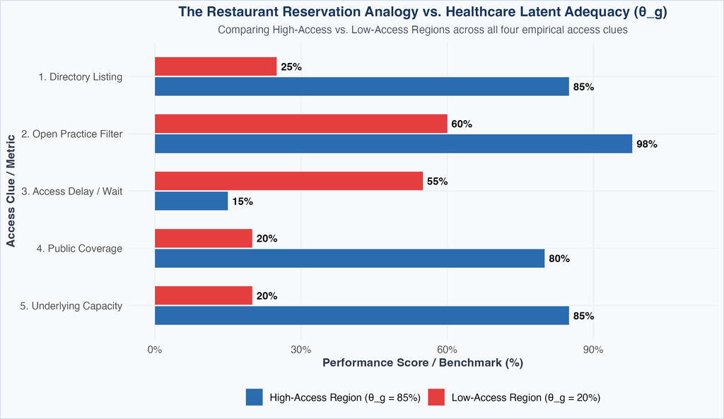

Figure 4: The Restaurant Reservation Analogy vs. Healthcare Latent Adequacy

### Conceptual Framework & Measurement Equations

In `urpssim`, true access capacity is modeled as a **latent regional parameter** $\theta_g \in [0, 1]$ for each geography/county $g$:

$$\theta_g \sim \text{Beta}(\alpha,
\beta), \quad \theta_g \in [0, 1]$$

The latent score $\theta_g$ is inferred simultaneously from four observed empirical access indicators through measurement equations:

1. **Mystery Caller Listing Appointment Success ($A_{\text{listing}, g}$)**:
   $$A_{\text{listing}, g} \sim \text{Binomial}(N_g,
   \, 0.10 + 0.70 \cdot \theta_g)$$
2. **Confirmed Eligible Practice Appointment Success ($A_{\text{eligible}, g}$)**:
   $$A_{\text{eligible}, g} \sim \text{Binomial}(N_g,
   \, 0.60 + 0.38 \cdot \theta_g)$$
3. **New Patient Appointment Wait Time ($W_g$, in days)**:
   $$W_g \sim \text{Normal}(60.0 - 45.0 \cdot
   \theta_g, \, \sigma_w^2)$$
4. **Medicaid Acceptance Rate ($M_g$)**:
   $$M_g \sim \text{Binomial}(N_g, \, 0.15 + 0.55
   \cdot \theta_g)$$

### Bayesian History Matching & Implausibility Metric

$$I(x) = \frac{|\mathrm{E}(f(x)) -
z|}{\sqrt{\mathrm{V}(f(x)) + \sigma_{\text{obs}}^2 +
\sigma_{\text{disc}}^2}}$$

## Figure 5: Joint Bayesian Latent Adequacy ($\theta_g$) Measurement & Regional Sensitivity

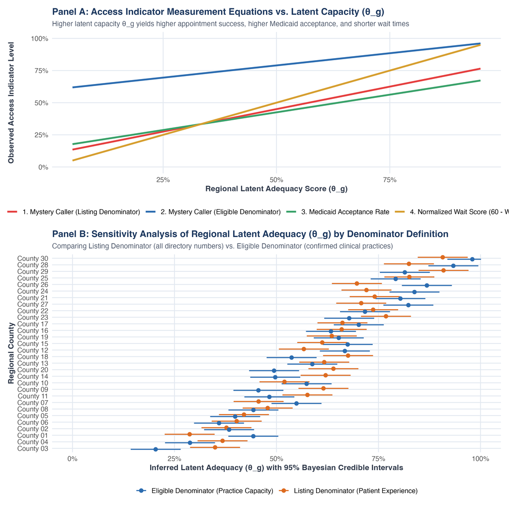

Figure 5: Joint Bayesian Latent Adequacy Measurement Equations & Regional Sensitivity Analysis